# mapping_R Markup

## Introduction to R packages for geospatial data

This tutorial introduces a variety of R packages that may be used to manipulate and visualize geospatial data in R. Below we provide short descriptions of the packages used in each example throughout this tutorial, which can to be installed with the following code:

```r
install.packages(c("acs", "choroplethr", "choroplethrMaps", "maptools", "rgeos",
    "mapproj", "RColorBrewer", "maps", "geosphere", "rgdal", "reshape", "ggplot2"))
```

## Brief Overview:

# EXAMPLE 1: Mapping Census Data

*This example introduces how to access and plot American Community Survey (ACS) yearly census data by the U.S. Census Bureau through choropleth maps.*

Packages used: **ACS**, **choroplethr**, **choroplethrMaps**  
After installing packages (see introduction), load needed packages:

```r
library(acs)
library(choroplethr)
library(choroplethrMaps)
```

We need an api key to access the ACS data. Visit http://api.census.gov/data/key_signup.html, request a key, and paste it into the line below:

```r
api.key.install("<ACS API key>")
```

Great, now we have access to the census data. Table B19301 contains per capita income for the year of 2011. Lets plot it!

```r
county_choropleth_acs(tableId = "B19301")
```

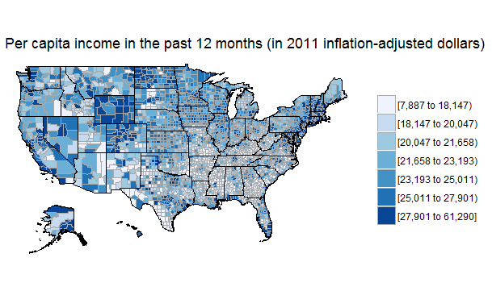

US county chloropleth using ACS per capita income data

To see the description of a function and its arguments in R, place a “?” before its name:

```r
`?`(county_choropleth_acs)
```

You can explore the ACS data on the Census Bureau’s website: http://factfinder.census.gov/faces/nav/jsf/pages/searchresults.xhtml Be sure to set the dataset to one of the ACS sources under Topics -> dataset. Use the ID column to find your tableID variable. Here’s another example to get you started playing around with these functions:

```r
state_choropleth_acs("B01002", num_colors = 1, zoom = c("texas", "louisiana",
    "mississippi", "alabama", "georgia", "florida"))
```

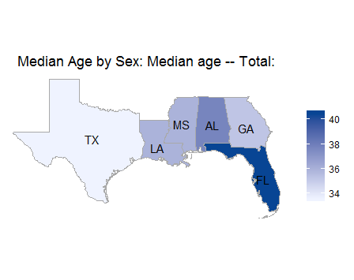

# EXAMPLE 2: Working with Shapefiles, Projections, and Visualization

*This example loads and plots both polygon and point shapefiles, uses the `rgdal` library to change projections, uses the `over` function to join datasets, and provides a few visualization examples.*

Packages used: **maptools, rgdal, RColorBrewer, ggplot2**  
After installing packages (see introduction), load needed packages:

```r
library(maptools)
library(rgdal)
library(RColorBrewer)
library(ggplot2)
```

In this example we will work with the data provided along with this tutorial. **Make sure you have unzipped the folder county_census before proceeding!** The following prompts you to select the provided county census shapefiles at the path …county_census/County_2010Census_DP1.shp.

```r
counties <- readShapeSpatial(file.choose(), proj4string = CRS("+proj=longlat +datum=WGS84"))
```

Note that the second parameter of the maptools function `readShapeSpatial` was a string representing the projection of the data, called a `prj4` string. So far we’ve used “+proj=longlat +datum=WGS84”, which is simply unprojected longitude and latitude coordinates.

Inspect the first few rows of the counties data to get a feel for its structure:

```r
head(counties@data)
```

Census data assigns codes to counties using the Federal Information Processing Standard (FIPS). A FIPS code starts with two digits representing the state, and is followed by three digits representing the county. For example, Florida is 12 and Clay County Florida is 12019. To select all the counties in Florida we can use a regular expression matching all codes that start with “12”:

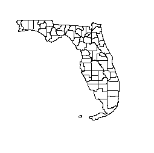

```r
florida <- counties[substring(counties$GEOID10, 1, 2) == "12", ]
plot(florida)
```

You can look up other state and county codes using the U.S. Census Bureau site: https://www.census.gov/geo/reference/codes/cou.html

### Projection and Layering with RGDAL

Next we’ll work more with projections using library `rgdal`. We’re going to read in a shape file of cultural points in Florida from the supplied data, again using function `readShapeSpatial()`. We know already that our cultural centers layer uses NAD83(HARN) / Florida GDL Albers. We can make the EPSG data frame of projections to find the `prj4` string for this projection (use `?make_EPSG()` to find out more about this table):

```r
library(rgdal)
EPSG <- make_EPSG()
```

We can use regular expressions to search the note field of `EPSG` for any that refer to Florida:

```r
EPSG[grep("florida", EPSG$note, ignore.case = TRUE), 1:2]
```

```
##       code                                     note
## 705   2236            # NAD83 / Florida East (ftUS)
## 706   2237            # NAD83 / Florida West (ftUS)
## 707   2238           # NAD83 / Florida North (ftUS)
## 1245  2777             # NAD83(HARN) / Florida East
## 1246  2778             # NAD83(HARN) / Florida West
## 1247  2779            # NAD83(HARN) / Florida North
## 1349  2881      # NAD83(HARN) / Florida East (ftUS)
## 1350  2882      # NAD83(HARN) / Florida West (ftUS)
## 1351  2883     # NAD83(HARN) / Florida North (ftUS)
## 1553  3086             # NAD83 / Florida GDL Albers
## 1554  3087       # NAD83(HARN) / Florida GDL Albers
## 1978  3511         # NAD83(NSRS2007) / Florida East
## 1979  3512  # NAD83(NSRS2007) / Florida East (ftUS)
## 1980  3513   # NAD83(NSRS2007) / Florida GDL Albers
```

[output cut: 17 more lines]

We see the code we’re looking for is 3087. Extract the `prj4` string from this dataframe:

```r
subset(EPSG, code == 3087)
prjstring <- subset(EPSG, code == 3087)$prj4
```

Inspect our `prjstring` variable if you want to see the format of the `prj4` variable.

Now that we have the appropriate `prj4` we can read in the cultural centers data. The following prompts you to select the shape file. Select the actual `.shp` file in the provided data from …cultural_centers/gc_culturecenter_oct15.shp.

```r
cultural <- readShapeSpatial(file.choose(), proj4string = CRS(prjstring))
```

Before we overlay the cultural points, we need to transform this layer to match that of the Florida counties layer - simple longitude and latitude in WGS84:

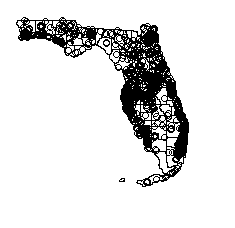

```r
cultural_proj <- spTransform(cultural, CRS("+proj=longlat +datum=WGS84"))

plot(florida)
points(cultural_proj)
```

You can play around with the symbology for your map with some additional arguments in the `points` function. For example:

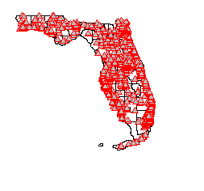

```r
plot(florida)
points(cultural_proj, cex = 0.8, pch = 24, col = 554, bg = "grey")
```

## join polygon data to points

```r
county_data <- over(cultural_proj, florida)
cultural_proj$pop <- county_data$DP0010001
```

## set colors

```r
library(RColorBrewer)
```

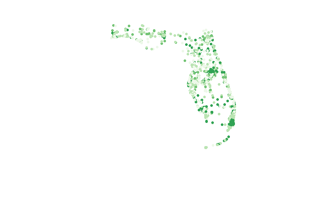

```r
brks <- c(0.5, 1, 1.5, 2) * 1e+06
cols <- brewer.pal(5, "Greens")

mapcols <- cols[findInterval(cultural_proj$pop, vec = brks)]
plot(cultural_proj, col = mapcols, pch = 20)
```

#### base R instructions for choropleth

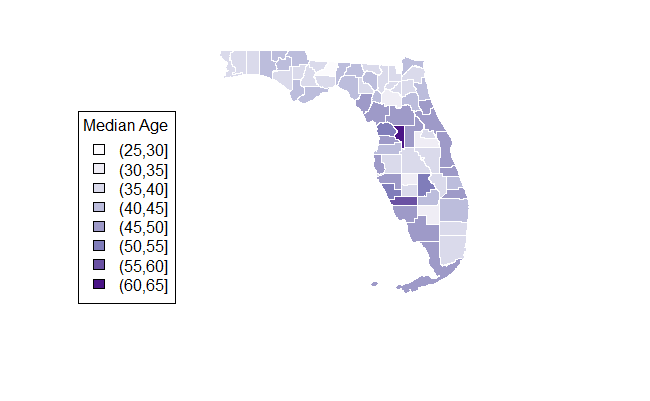

```r
brks <- c(25, 30, 35, 40, 45, 50, 55, 60, 65)
cols <- brewer.pal(8, "Purples")

mapcols <- cols[findInterval(florida$DP0020001, vec = brks)]
plot(florida, col = mapcols, border = "white")

legend("bottomleft", legend = levels(cut(florida$DP0020001, brks)), fill = cols,
    title = "Median Age")
```

### using ggplot2

```r
library(ggplot2)
```

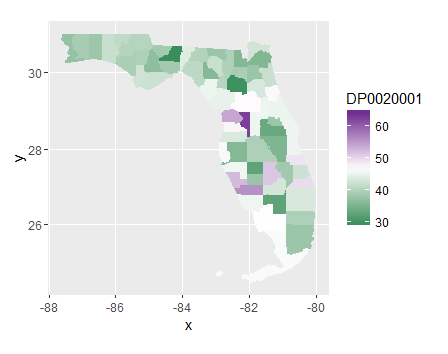

```r
fl_shapes <- fortify(florida, region = "GEOID10")

ggplot() + geom_map(data = as.data.frame(florida), aes(map_id = GEOID10, fill = DP0020001),
    map = fl_shapes) + expand_limits(x = fl_shapes$long, y = fl_shapes$lat) +
    scale_fill_gradient2(low = "seagreen", mid = "white", high = "darkorchid4",
        midpoint = 47, limits = c(29, 65)) + coord_map(projection = "mercator")
```

# EXAMPLE 3: Migration Distances Map

*This example loads both a shapefile and .csv file, transforms the data set with a melt function, and writes a function that maps the distance data contained in the .csv file.*

Packages used: **maps, geosphere, reshape, maptools**  
After installing packages (see introduction), load needed packages:

```r
library(maps)
library(geosphere)
library(reshape)
library(maptools)
```

### Import shapefile and .csv file

Import shapefile of map of continental United States. Choose `state_shapes/tl_2014_us_state.shp` file when prompted.

```r
state <- readShapeSpatial(file.choose())
```

Import data file of migration distances between U.S.A. states. Choose `state_migrations_2014.csv` file when prompted.

```r
migration <- read.csv(file.choose())
```

Extract state names and geographic coordinate (latitude and longitude) information from `state` shapefile; save it into a data frame called `centrs`.

```r
centrs <- data.frame(as.character(state@data$NAME), coordinates(state))
colnames(centrs) <- c("name", "long", "lat")
```

### Reshape data with melt function

Redefine the `migration` data set to only include columns 1 & 6-through-56 of data. Then use `melt` function from `reshape` package to transform data set into rows representing unique instances of data, based on a selected variable id (in our case, the `from_state` variable). *For more on the `melt` function, see https://www.r-bloggers.com/melt/.*

```r
migration <- migration[c(1, 6:56)]
long_mig <- melt(migration, id.vars = "from_state")
```

### Create a mapping function

```r
draw_from_state <- function(centrs, migrations, state_name, color = rgb(0, 0,
    0, alpha = 0.5)) {
    migrations$variable <- sub(".", " ", migrations$variable, fixed = TRUE)
    migrations <- migrations[migrations$variable == state_name & migrations$from_state !=
        state_name, ]
    for (i in 1:nrow(migrations)) {
        if (nrow(centrs[centrs$name == as.character(migrations[i, ]$from_state),
            ]) > 0) {
            from_long <- centrs[centrs$name == as.character(migrations[i, ]$from_state),
                ]$long
            from_lat <- centrs[centrs$name == as.character(migrations[i, ]$from_state),
                ]$lat
            to_long <- centrs[centrs$name == as.character(migrations[i, ]$variable),
                ]$long
            to_lat <- centrs[centrs$name == as.character(migrations[i, ]$variable),
                ]$lat
            number <- migrations[i, ]$value
            lines(gcIntermediate(c(from_long, from_lat), c(to_long, to_lat),
                n = 50, addStartEnd = TRUE), lwd = sqrt(number)/50, col = color)
        }
    }
}
```

### Using our mapping function: example 1

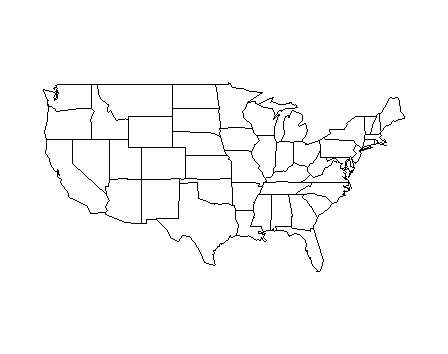

```r
map("state")
```

Now use written function to map migration distances from Florida.

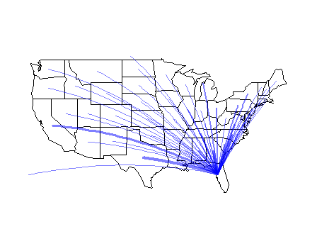

```r
draw_from_state(centrs, long_mig, "Florida", rgb(0, 0, 1, 0.5))
```

### Using our mapping function: example 2

First draw a world map (limited to North and Central America by creating x- and y-coordinate limits), and subsquently use written function to map migration distances from Wyoming onto map.

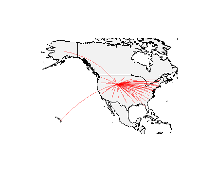

```r
xlim <- c(-171.738281, -56.601563)
ylim <- c(12.039321, 71.856229)
map("world", col = "#f2f2f2", fill = TRUE, bg = "white", lwd = 0.05, xlim = xlim,
    ylim = ylim)
draw_from_state(centrs, long_mig, "Wyoming", rgb(1, 0, 0, 0.5))
```